# STAT 516 Lec 11

# VO$_2$ max

```r
y1. <- mean(vo2max$chg[vo2max$grp == "aerobic"])
y2. <- mean(vo2max$chg[vo2max$grp == "running"])

x1. <- mean(vo2max$age[vo2max$grp == "aerobic"])
x2. <- mean(vo2max$age[vo2max$grp == "running"])
x.. <- mean(vo2max$age)

bhat <- coef(lm_out)[3]

y1.adj <- y1. - bhat * (x1. - x..)
y2.adj <- y2. - bhat * (x2. - x..)
```

# VO$_2$ max

```r
n1 <- 6
n2 <- 6
alpha <- 0.05

tval <- qt(1-alpha/2,N-a-1)
age1 <- vo2max$age[vo2max$grp == "aerobic"]
age2 <- vo2max$age[vo2max$grp == "running"]
Ex1 <- sum((age1 - mean(age1))^2)
Ex2 <- sum((age2 - mean(age2))^2)
Exx <- Ex1 + Ex2

se1 <- sqrt(MSE) * sqrt(1/n1 + (x1. - x..)^2 / Exx)
lo1 <- y1.adj - tval * se1
up1 <- y1.adj + tval * se1

se2 <- sqrt(MSE) * sqrt(1/n2 + (x2. - x..)^2 / Exx)
lo2 <- y2.adj - tval * se2
up2 <- y2.adj + tval * se2

se12 <- sqrt(MSE) * sqrt(1/n1 + 1/n2 + (x1. - x2.)^2 / Exx)
lo12 <- y1.adj - y2.adj - tval * se12
up12 <- y1.adj - y2.adj + tval * se12
```

# VO$_2$ max

Mean change in VO$_2$ max in aerobic and running groups

|  | Unadjusted | Age-adjusted(CI) |
| --- | --- | --- |
| Aerobic | 7.71 | 5.19 (2.46,7.92) |
| Running | -2.77 | -0.25 (-2.98,2.48) |
| Aerobic - Running | 10.47 | 5.44 (1.38,9.51) |

# Soybean data from Dr. Longnecker’s notes

Soybean plants assigned to three greenhouse conditions:

- Supplemental lighting (SL)
- Partial shading (PS)
- Control (C).

The response was seed yield. The pre-treatment height of each plant was also recorded.

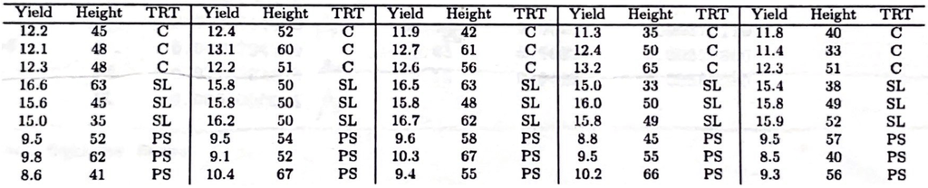

Do the greenhouse conditions effect the seed yield?

What is the role of plant height (proxy for plant vigor)?

# Soybean data

```r
soybean <- data.frame(yield = c(12.2,12.1,12.3,16.6,15.6,15.0,9.5,9.8,8.6,
                                12.4,13.1,12.3,15.8,15.8,16.2,9.5,9.1,10.4,
                                11.9,12.7,12.6,16.5,15.8,16.7,9.6,10.3,9.4,
                                11.3,12.4,13.2,15.0,16.0,15.8,8.8,9.5,10.2,
                                11.8,11.4,12.3,15.4,15.8,15.9,9.5,8.5,9.3),
                      trt = as.factor(rep(c(rep("C",3),rep("SL",3),rep("PS",3)),5)),
                      height = c(45,48,48,63,45,35,52,62,41,
                                 52,60,51,50,50,50,54,52,67,
                                 42,61,56,63,48,62,58,67,55,
                                 35,50,65,33,50,49,45,55,66,
                                 40,33,51,38,49,52,57,40,56))
head(soybean,n = 12)
```

```
   yield trt height
1   12.2   C     45
2   12.1   C     48
3   12.3   C     48
4   16.6  SL     63
5   15.6  SL     45
6   15.0  SL     35
7    9.5  PS     52
8    9.8  PS     62
9    8.6  PS     41
10  12.4   C     52
11  13.1   C     60
12  12.3   C     51
```

# Soybean data

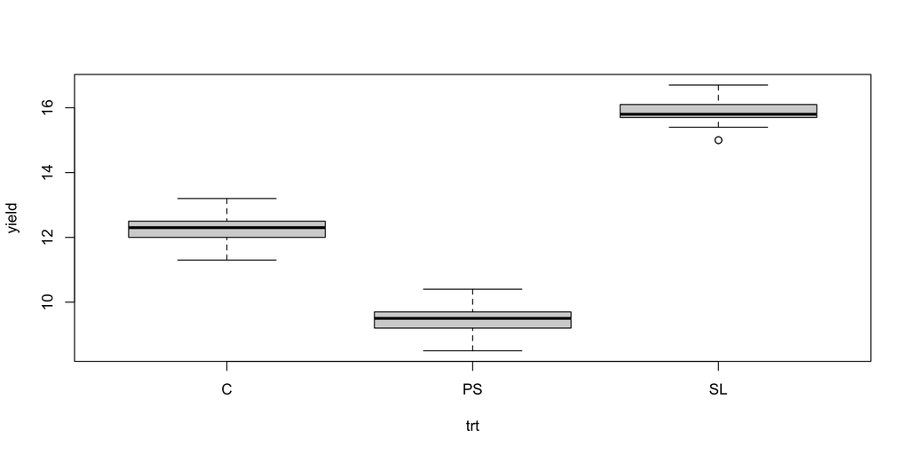

```r
boxplot(yield~trt, data = soybean)
```

# Soybean data

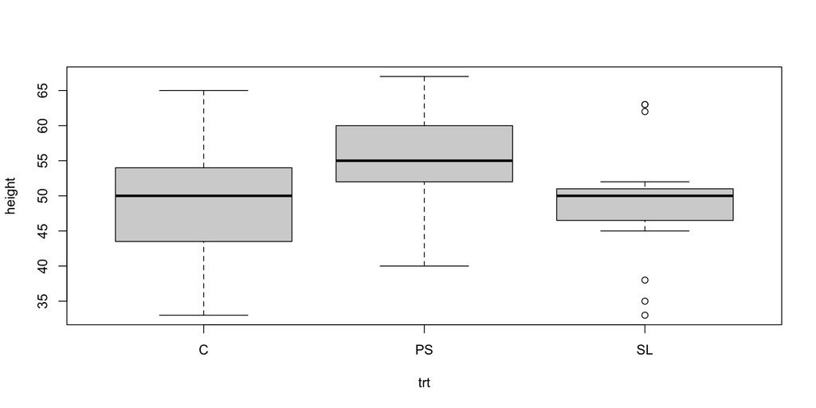

```r
boxplot(height~trt, data = soybean)
```

# Soybean data

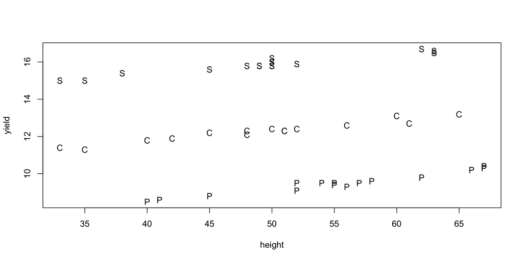

```r
plot(yield ~ height, pch = as.character(trt), data = soybean)
```

# ANCOVA allowing different slopes in each group

Assume
$$Y_{ij} = \mu + \tau_i + (\beta + (\tau\beta)_i)x_{ij} + \varepsilon_{ij}$$
for $i = 1,\dots,a$, $j = 1,\dots,n_i$, where

- $Y_{ij}$ is the response of EU $j$ in treatment group $i$.
- $\mu$ is a baseline or overall mean.
- the $\tau_i$ are treatment effects.
- the $x_{ij}$ are covariate values measured on the EUs.
- $\beta$ is a slope coefficient expressing the effect of the covariate.
- the $(\tau\beta)_i$ allow interaction between the treatment and the covariate.
- the $\varepsilon_{ij}$ are independent $\text{Normal}(0,\sigma_{\varepsilon}^2)$ error terms.
- $n_1 + \dots + n_a = N$. Unbalancedness not an issue.

Set $\mu_i = \mu + \tau_i$ and $\beta_i = \beta + (\tau\beta)_i$ for $i =1,\dots,a$.

# Parameter constraints in multiple slopes model

- There are $a$ treatment groups and $a$ covariate slopes.
- The model has $2(a + 1)$ parameters, which is two too-many.
- R will set $\tau_1 = 0$ and $(\tau\beta)_1 = 0$ to make all parameters estimable.

# Soybean data

```r
lm_out <- lm(yield ~ trt + height + trt:height, data = soybean)
summary(lm_out)
```

```
Call:
lm(formula = yield ~ trt + height + trt:height, data = soybean)

Residuals:
     Min       1Q   Median       3Q      Max
-0.23473 -0.08875 -0.00395  0.05764  0.29332

Coefficients:
             Estimate Std. Error t value Pr(>|t|)
(Intercept)   9.50057    0.18193   52.22  < 2e-16 ***
trtPS        -3.63959    0.28553  -12.75  1.7e-15 ***
trtSL         3.71305    0.25858   14.36  < 2e-16 ***
height        0.05630    0.00364   15.45  < 2e-16 ***
trtPS:height  0.00910    0.00537    1.69    0.098 .
trtSL:height -0.00244    0.00518   -0.47    0.641
---
Signif. codes:  0 '***' 0.001 '**' 0.01 '*' 0.05 '.' 0.1 ' ' 1

Residual standard error: 0.126 on 39 degrees of freedom
Multiple R-squared:  0.998, Adjusted R-squared:  0.998
F-statistic: 4.05e+03 on 5 and 39 DF,  p-value: <2e-16
```

# Soybean data

```r
parms <- coef(lm_out)
parms
```

```
 (Intercept)        trtPS        trtSL       height trtPS:height trtSL:height
     9.50057     -3.63959      3.71305      0.05630      0.00910     -0.00244
```

# Soybean data

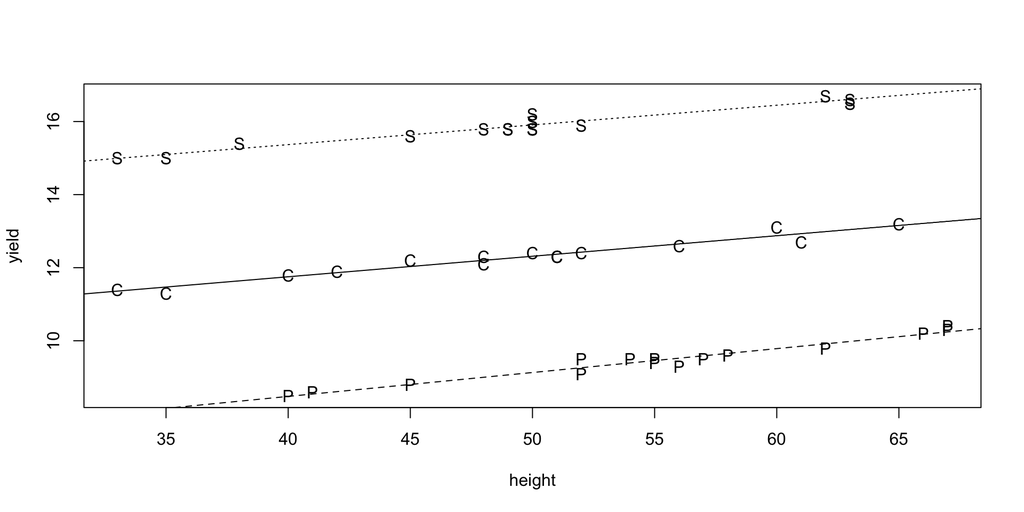

```r
plot(yield ~ height, pch = as.character(trt), data = soybean)
abline(parms[1],parms[4],lty = 1)
abline(parms[1] + parms[2],parms[4] + parms[5],lty = 2)
abline(parms[1] + parms[3],parms[4] + parms[6],lty = 3)
```

# An F-test for equal slopes

Define the error sums of squares:

| SS | Formula |
| --- | --- |
| $\operatorname{SS}_{\operatorname{Error}}(\text{Full})$ | $\sum_{i=1}^a\sum_{j=1}^{n_{ij}}(Y_{ij} - (\hat \mu + \hat \tau_i + (\hat \beta + (\hat{\tau\beta})_i) x_{ij}))^2$ |
| $\operatorname{SS}_{\operatorname{Error}}(\text{Equal slopes})$ | $\sum_{i=1}^a\sum_{j=1}^{n_{ij}}(Y_{ij} - (\hat \mu + \hat \tau_i + \hat \beta x_{ij}))^2$ |

Now set

$$\operatorname{F}_{\operatorname{T}\times\operatorname{C}}= \frac{[\operatorname{SS}_{\operatorname{Error}}(\text{Equal slopes}) - \operatorname{SS}_{\operatorname{Error}}(\text{Full})] / (a-1)}{\operatorname{SS}_{\operatorname{Error}}(\text{Full})/(N-2a)}$$

Reject $H_0$: *Equal slopes* at $\alpha$ if $\operatorname{F}_{\operatorname{T}\times\operatorname{C}}> F_{a-1,N-2a,\alpha}$.

# Soybean data

```r
lm_eqslp <- lm(yield ~ trt + height, data = soybean) # equal slopes model
lm_full <- lm(yield ~ trt + height + trt:height, data = soybean) # full model

SSE_eqslp <- sum(lm_eqslp$resid^2)
SSE_full <- sum(lm_full$resid^2)

a <- 3
N <- nrow(soybean)

FTrtCov <- ((SSE_eqslp - SSE_full) / (a-1)) / (SSE_full / (N - 2*a))
pTrtCov <- 1 - pf(FTrtCov,a-1,N - 2*a)
```

# Soybean data

Same as interaction p value from `anova()` on the `lm()` output.

```r
anova(lm_out)
```

```
Analysis of Variance Table

Response: yield
           Df Sum Sq Mean Sq F value Pr(>F)
trt         2  308.1   154.1 9770.80 <2e-16 ***
height      1   11.4    11.4  722.29 <2e-16 ***
trt:height  2    0.1     0.0    2.49  0.096 .
Residuals  39    0.6     0.0
---
Signif. codes:  0 '***' 0.001 '**' 0.01 '*' 0.05 '.' 0.1 ' ' 1
```

# When slopes are unequal

If we reject $H_0$: *Equal slopes*, then

- We can compute covariate-adjusted means with the different slopes.
- We can compare the covariate adjusted means—but the CI formulas are different from the ones above (details omitted).

# References

Kuehl, R. O. 2000. *Design of Experiments: Statistical Principles of Research Design and Analysis*. Duxbury/Thomson Learning.